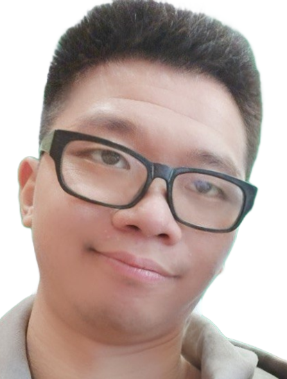

# 梁嘉杰

## 个人总结

持有伦敦大学政治经济学院经济与金融双学士学位，具备中、粤、英。具有一对一线上雅思教学经验，能根据学生当前成绩与目标分数设计个人化课程、整理学习资料，并持续追踪进度与家长沟通。曾协助学生掌握雅思四大考核范畴，最终达成7.0分目标。熟悉Microsoft Word、Powerpoint及Excel，擅长将复杂内容归纳为清晰、易理解的学习重点。

## 教育背景

2015.09-2018.06 | **经济与金融学士** | 伦敦大学经济学院

2013.10-2015.04 | **工商管理大专** | 新加坡经济管理学院

## 工作经验

2024.03-2026.03 | 英语雅思教师

- 为 IELTS Academic/General Training考生提供线上一对一及小班授课，覆盖听、说、读、写四项技能，并根据学生基础、目标分数和考试时间制定个性化学习计划。
- 设计课程计划及配套教学资料，包括讲义、词汇表、语法练习、写作范文、口语题库和模拟测试。
- 依据 IELTS 评分标准对学生的写作和口语进行诊断、批改和反馈，帮助学生改进语法准确性、词汇使用、逻辑组织、流利度和发音。
- 通过阶段测评、模拟考试和学习数据跟踪，持续调整教学策略并提供课后学习指导。
- 帮助25名学生的英语水平**从 CEFR A1~A2提升至B2~C1**；指导22名 学生备考，学生平均模拟成绩**提高2.0~2.5**分。
- 制作4套教学资源，使学生作业完成率达到95%，课程满意度达到4/5。

2022.03-2023.11 | 跨境店铺运营

###### 广州乘风兄弟有限公司

- 负责 B2B 跨境电商店铺日常运营，制作流量日报并监测曝光量、访问量、访客来源、转化率及广告投放表现。
- 负责商品上传及全生命周期维护，优化商品标题、关键词、图片、详情页和规格参数，确保产品信息准确、完整且符合平台规范。
- 建立并维护包含产品类型、尺寸、材质及技术参数的商品资料库，为业务员报价、客户沟通和销售跟进提供标准化信息支持。
- 根据平台活动和营销目标策划并搭建活动落地页，优化页面结构、产品卖点及询盘入口，配合公司执行线上推广活动。
- 基于网站流量趋势、访客行为和产品表现制定广告投放策略，监控曝光、点击、点击成本、转化率及广告投入产出，动态优化预算和投放内容。
- 通过优化商品信息、店铺内容及运营规范，在**1年内将店铺评级从0星提升至3星**。
- 活动期间实现 单月累计曝光量15,000+，并将店铺整体转化率从**0.8%提升至2.5%**，相对提升约 212.5%。

2021.01-2022.07 | 英语教师

###### 广州立贤教育培训中心

- 面向小学及初中学生及其家长开展学习需求分析，根据学生英语基础、年级和学习目标制定个性化课程方案。
- 设计并编写分年级、分能力层级的教辅资料，包括词汇、语法、阅读、写作练习、阶段测试及错题复习材料。
- 通过分层教学、针对性辅导和阶段性测评，跟踪学生学习进度并及时调整教学内容及训练重点。
- 定期向家长反馈学生表现、成绩变化和待改进环节，提供课后学习建议，促进家校沟通与合作。
- 配合培训中心向本地小学及初中推广教辅服务、试课及优惠政策活动，协助拓展学校和家长渠道。
- 累计辅导超过**60**名不同年级的小学生，帮助学生考试平均分**从70分提升至90**分，平均提高**20**分。
- 课程满意度调查取得**4.5/5**分 平均评级。

## 技能&能力

English

Microsoft Excel

普通话

Microsoft Word

粤语

Microsoft Powerpoint